# Finding the ideal urban forest

Beau Lucas

# Context

I decided to explore the topic of urban forests for a few reasons:

1. Curiosity around the quality and depth of .gov datasets. Thus far, I am impressed.
2. The beautiful maps I’ve seen on #Rstats twitter lately, including work done by folks at [r-spatial](https://www.r-spatial.org/r/2018/10/25/ggplot2-sf.html) and others
3. Personal motivation in exploring my long-term moving options

# What is an urban forest?

My idea of an urban forest is a state that exhibits the following properties:

- **Ample greenspace.** The state should contain large swaths of undeveloped land. This could take the form of mountains, forests, trails, etc. I need to be able to escape into large swaths of greenspace without driving half the day.
- **Canopies on developed land.** Suburban and urban areas should also be green. I don’t want the https://en.wikipedia.org/wiki/Urban_heat_island effect, and want to feel more connected with nature where I live and work. California fails at this, as the majority of suburbs are concrete-dominant. Those that aren’t are either far away from jobs (think far Northern California) and/or wildfire risks.
- **Reasonably, but not overly developed.** It should be easy to find a high-paying job, economy should be stable, and proximity to modern amenities should be seamless. This makes it urban.

## Grabbing the data

This dataset is provided for free by the the [Northern Research Station of the USDA Forest Service](https://www.nrs.fs.fed.us/).

The data includes urban forest data with respect to the contiguous United States. The data was collected via *“…top-down aerial approaches and bottom-up field data collection”* as part of the [Resource Planning Act](https://www.fs.fed.us/research/rpa/).

Data is available at the state, county, and county sub-division level. The data consists of CSVs as well as GIS shapefiles.

A link to downloading the dataset can be found [here](https://www.nrs.fs.fed.us/data/urban/). To better understand the fields included in the data, there is also a helpful [metadata text file](https://www.nrs.fs.fed.us/data/urban/local-resources/documents/metasdata_shp.txt).

## Ample greenspace

The first thing I want to do is filter out states that lack forested land. To me, ample greenspace is satisfied when the state has a large percentage of forest coverage combined with a large total area of forested land.

### Forest coverage

Looking at forest coverage, the first thing that pops out is the green-ness of the east coast compared to the west. To be fair, looking at the state level can penalize certain states that exhibit a wide variance in biomes. Looking at `California` purely from this map, you would never guess it has the largest forest area in the contiguous US.

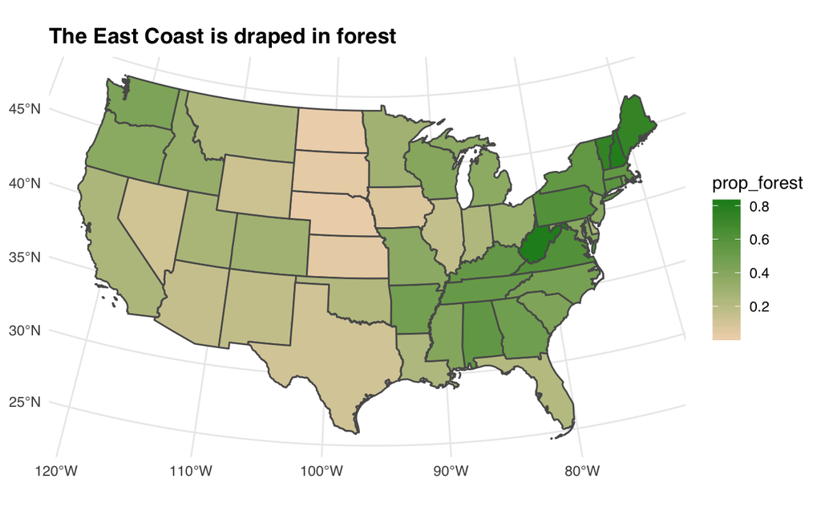

For a quick reduction, I’m setting my `Forest Coverage` cutoff at `20%`. Those below this are removed from consideration.

#### Not Enough Forest

| State | Prop Forest | Prop Developed | Prop Agriculture | Prop Shrub |
| --- | --- | --- | --- | --- |
| New Mexico | 16.7% | 1.1% | 2.0% | 48.5% |
| Illinois | 15.6% | 11.8% | 71.5% | 0.0% |
| Arizona | 15.3% | 2.0% | 2.2% | 72.1% |
| Wyoming | 12.7% | 0.8% | 3.9% | 52.0% |
| Nevada | 11.1% | 0.9% | 1.4% | 79.8% |
| Texas | 10.7% | 5.3% | 23.8% | 40.7% |
| Iowa | 7.0% | 7.4% | 80.1% | 0.2% |
| Kansas | 3.8% | 5.1% | 53.5% | 0.4% |
| South Dakota | 3.6% | 2.9% | 37.7% | 1.4% |
| Nebraska | 2.0% | 3.6% | 38.2% | 0.1% |
| North Dakota | 1.8% | 4.1% | 57.9% | 1.1% |

### Total amount of forested land

It’s not enough to be highly forested. A state should also have a large amount of forested land. When we plot this against a state’s forest coverage, we notice that some of the most green states are tiny. Notice the cluster of some of the smaller original colonies in the top left. While these states are some of the most forested in the country, their small size limits their outdoors potential.

Secondly, these states are all sandwiched inside the [Northeast megalopolis](https://en.wikipedia.org/wiki/Northeast_megalopolis).

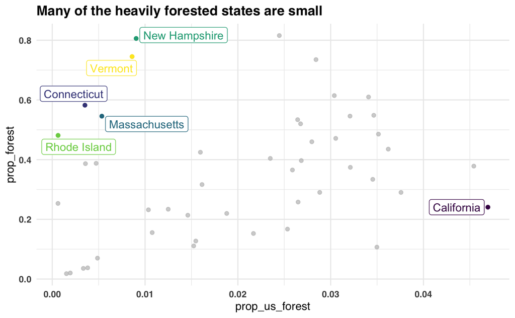

## Canopies on developed land

It’s important to be surrounded by greenspace without having to drive half of the day to the mountains.

If we look at the underlying GIS data, we also have a field named `tdevelop`. Examining the metadata, this field signals the total amount of developed land. Developed land follows classes 21-24 from the schema found here:

- [Multi-Resolution Land Characteristics Consortium](https://www.mrlc.gov/data/legends/national-land-cover-database-2011-nlcd2011-legend)

`tdevelop` thus captures a wide range of developments, from parks, single-family homes, and golf courses, all the way up to urban apartment complexes and factories. Since this is where most people will choose to live, measuring the amount of tree coverage in developed land is an important measure.

The dataset also contains a field `devcan`, which measures the amount of tree canopy in developed land.

While there is a strong trend between how forested a state is and how much canopy their developed land contains, some states don’t fit this.

Let’s compare how much of a state’s land is covered by forest versus how much of its developed land is covered in canopy.

Notice the strong linear relationship between the two variables. I’m interested in filtering out states that have less than “expected” levels of developed canopy.

### Predicting developed canopy

Just for fun, let’s fit a simple linear regression to determine which states exhibit less developed canopy than expected.

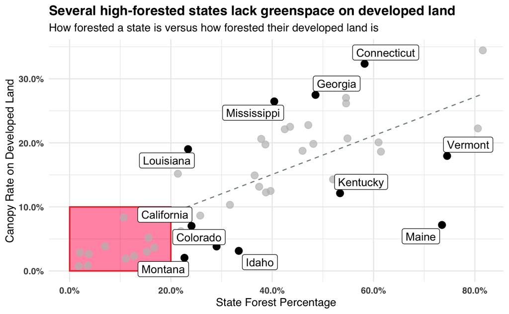

#### Developed Canopy vs. Total Canopy

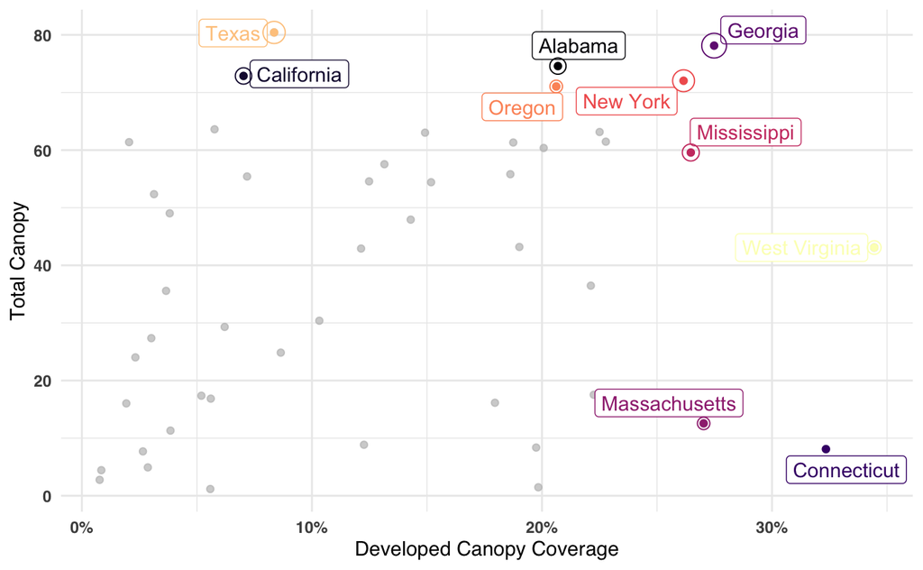

We’ve now established two filters:

- Forest `>=20%` of land mass
- Developed canopy better than average

## Reasonably, but not overly developed

Of the remaining states, I still need to find one that has an adequate economy.

- For myself, development cutoff is 10%

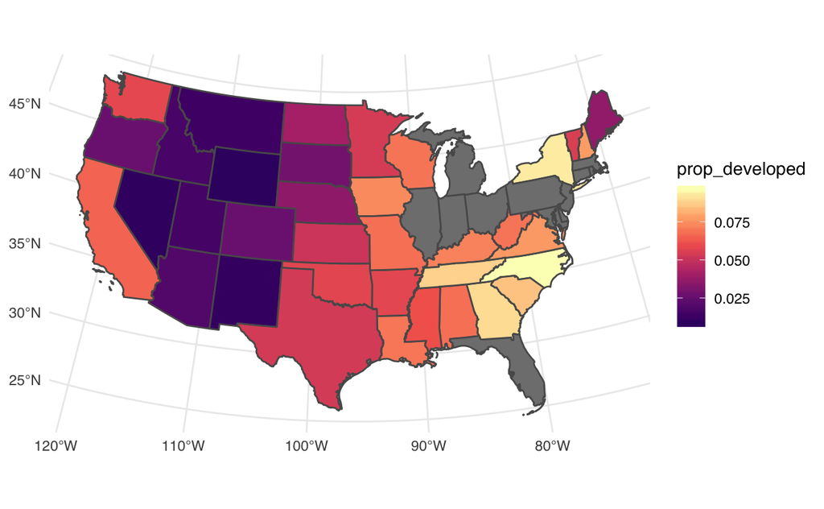

```
## # A tibble: 12 x 2
##    name00        prop_developed
##    <fct>                  <dbl>
##  1 Rhode Island           0.296
##  2 New Jersey             0.247
##  3 Massachusetts          0.244
##  4 Connecticut            0.237
##  5 Ohio                   0.143
##  6 Florida                0.143
##  7 Maryland               0.122
##  8 Illinois               0.118
##  9 Pennsylvania           0.109
## 10 Michigan               0.108
## 11 Indiana                0.104
## 12 Delaware               0.102
```

## What’s the deal with California?

Most of California is undeveloped. However, these are areas where practically nobody lives.

In California, there is plenty of forest in the Sierra Nevada mountain range. But this is in mountainous, undeveloped territory. Living there with modern amenities and proximity to high-skilled tech jobs is not possible. In fact, to register as forest land in the dataset, land must be purely undeveloped.

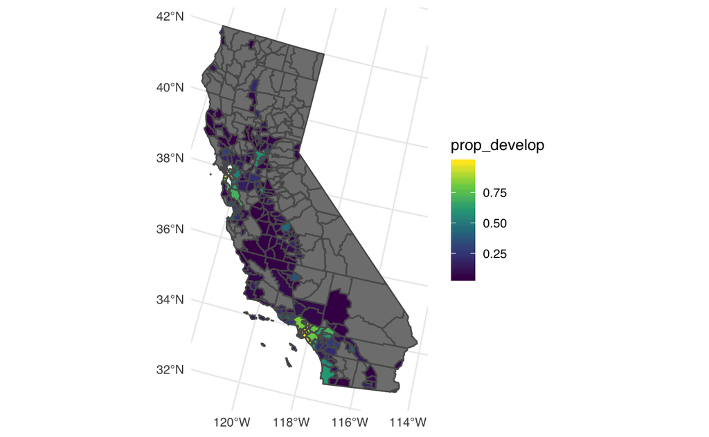

If we look at the counties where people live, we get a different story.

Highlighted counties are those that contribute ~3/4 of California’s population. The majority of California’s forest land is highly remote.

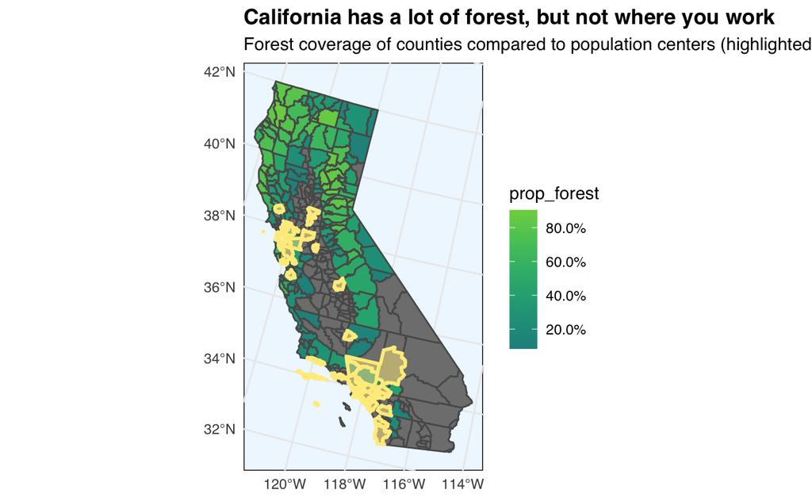

Another way to compare states is to see how much of their population constitutes their land mass. In other words, comparing the cumulative proportion of population with the cumulative proportion of land mass.

### Population Proportion vs. Land Mass

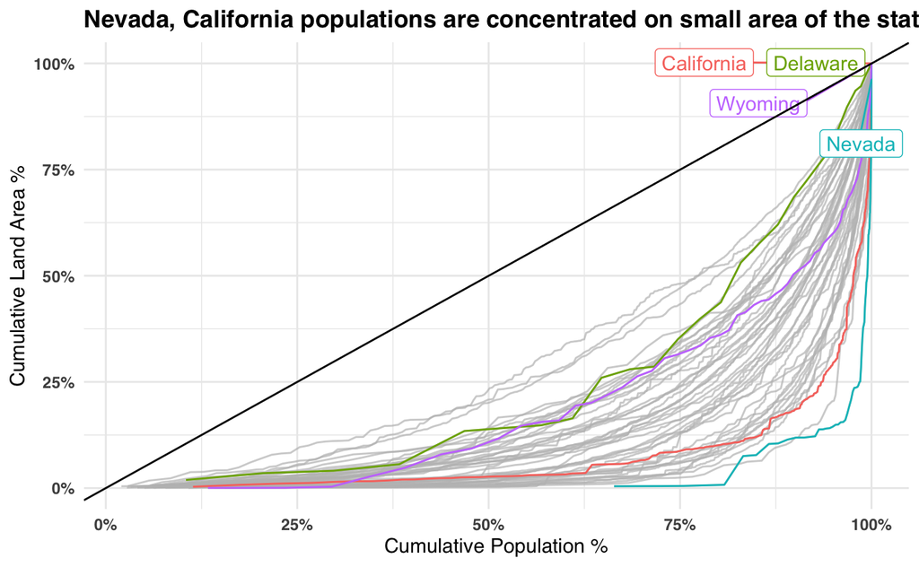